# Assignment4

Claire Madden

5/28/2019

```r
library(tidyverse)
data<-read_csv("HW4Data.csv")
```

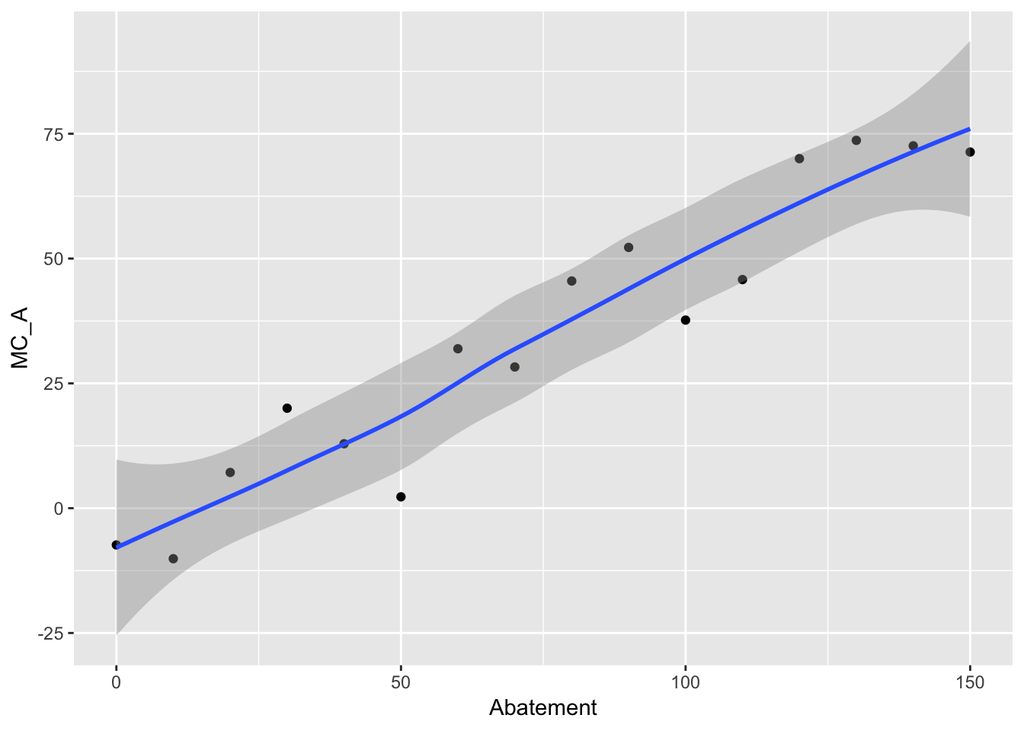

```r
graph_data<-read_csv("HW4Data_edited.csv")
explore_graphA <- ggplot(data, aes(x=Abatement, y=MC_A))+
  geom_point()+
  geom_smooth()

explore_graphA
```

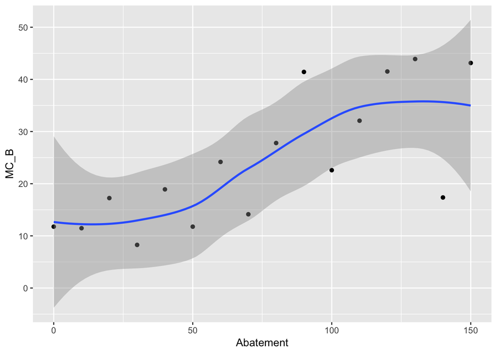

```r
# looks linear for sure

explore_graphB <- ggplot(data, aes(x=Abatement, y=MC_B))+
  geom_point()+
  geom_smooth()

explore_graphB
```

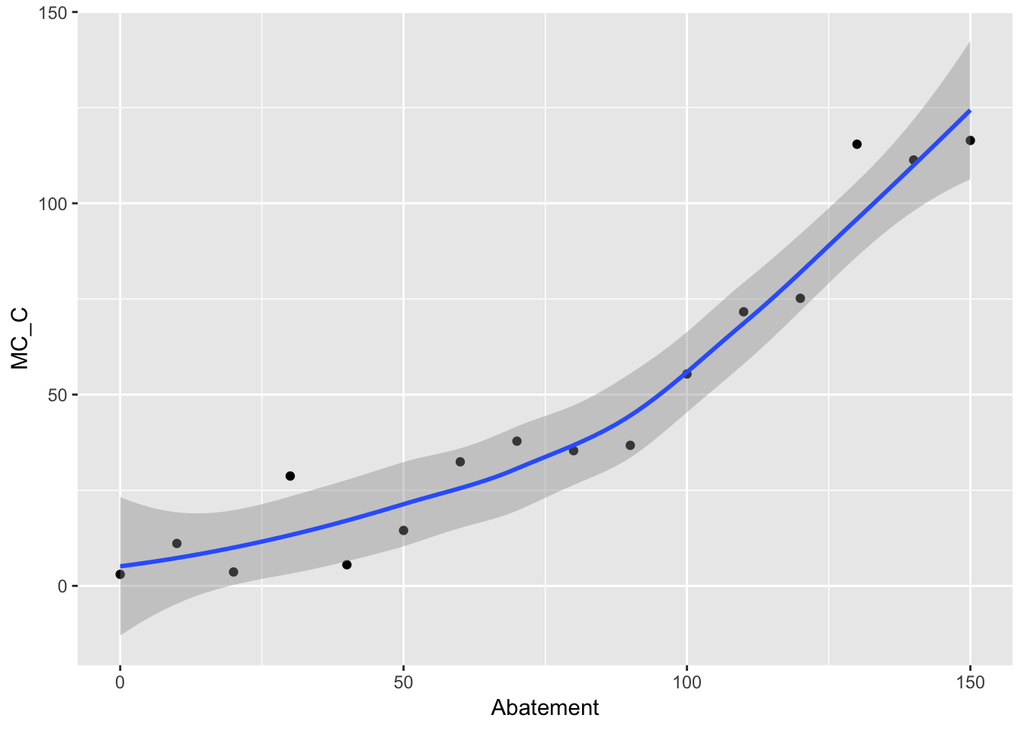

```r
# logistic maybe, cubic?

explore_graphC <- ggplot(data, aes(x=Abatement, y=MC_C))+
  geom_point()+
  geom_smooth()

explore_graphC
```

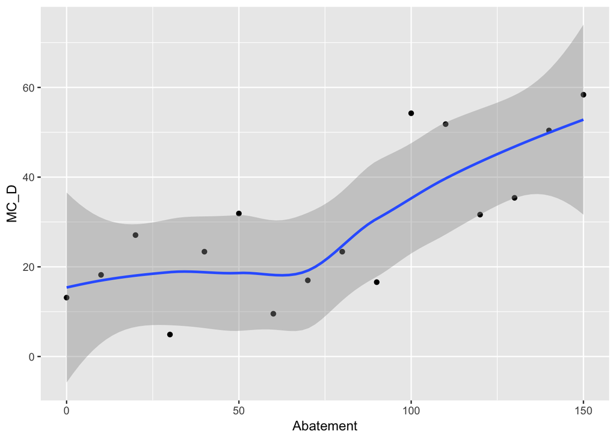

```r
# close to linear, maybe exponential

explore_graphD <- ggplot(data, aes(x=Abatement, y=MC_D))+
  geom_point()+
  geom_smooth()

explore_graphD
```

```r
# hard to see trend, maybe linear would be closest to accurate?
```

1. Write down a plausible functional form for the marginal cost of abatement for sector A. Use regression analysis to estimate the parameters of that function. Repeating this for sectors B, C, and D will give you a model of the marginal cost of abatement function for each sector. How well do your models fit the data for each sector? You may need to experiment with different functional forms. Produce a plot of the estimated marginal abatement cost functions in all four sectors (this plot should go in your memo).

```r
MC_A_model <- lm(MC_A ~ Abatement, data = data)

summary(MC_A_model)
```

```
##
## Call:
## lm(formula = MC_A ~ Abatement, data = data)
##
## Residuals:
##      Min       1Q   Median       3Q      Max
## -17.9221  -6.7176   0.8734   7.4986  11.3643
##
## Coefficients:
##             Estimate Std. Error t value Pr(>|t|)
## (Intercept) -8.64448    4.25720  -2.031   0.0617 .
## Abatement    0.57684    0.04836  11.928 1.01e-08 ***
## ---
## Signif. codes:  0 '***' 0.001 '**' 0.01 '*' 0.05 '.' 0.1 ' ' 1
##
## Residual standard error: 8.917 on 14 degrees of freedom
## Multiple R-squared:  0.9104, Adjusted R-squared:  0.904
## F-statistic: 142.3 on 1 and 14 DF,  p-value: 1.01e-08
```

```r
A_int <- MC_A_model$coefficients[1]
A_slope <- MC_A_model$coefficients[2]
#p-value: 1.01e-08
#R-squared: 0.904, pretty good fit

MC_B_model <- lm(MC_B ~ Abatement, data = data)
summary(MC_B_model)
```

```
##
## Call:
## lm(formula = MC_B ~ Abatement, data = data)
##
## Residuals:
##     Min      1Q  Median      3Q     Max
## -19.781  -6.702   2.049   3.968  14.226
##
## Coefficients:
##             Estimate Std. Error t value Pr(>|t|)
## (Intercept)  9.31770    4.09094   2.278 0.038966 *
## Abatement    0.19874    0.04647   4.277 0.000767 ***
## ---
## Signif. codes:  0 '***' 0.001 '**' 0.01 '*' 0.05 '.' 0.1 ' ' 1
##
## Residual standard error: 8.569 on 14 degrees of freedom
## Multiple R-squared:  0.5664, Adjusted R-squared:  0.5355
## F-statistic: 18.29 on 1 and 14 DF,  p-value: 0.0007672
```

```r
B_int <- MC_B_model$coefficients[1]
B_slope <- MC_B_model$coefficients[2]
#p-value: 0.0007672
#R-squared: 0.5355, probably want to change this one for a better fit?

MC_C_model <- lm(MC_C ~ Abatement, data = data)
summary(MC_C_model)
```

```
##
## Call:
## lm(formula = MC_C ~ Abatement, data = data)
##
## Residuals:
##     Min      1Q  Median      3Q     Max
## -22.153 -11.773  -2.939  13.591  25.195
##
## Coefficients:
##              Estimate Std. Error t value Pr(>|t|)
## (Intercept) -11.65503    6.96282  -1.674    0.116
## Abatement     0.78383    0.07909   9.910 1.04e-07 ***
## ---
## Signif. codes:  0 '***' 0.001 '**' 0.01 '*' 0.05 '.' 0.1 ' ' 1
##
## Residual standard error: 14.58 on 14 degrees of freedom
## Multiple R-squared:  0.8752, Adjusted R-squared:  0.8663
## F-statistic: 98.21 on 1 and 14 DF,  p-value: 1.044e-07
```

```r
C_int <- MC_C_model$coefficients[1]
C_slope <- MC_C_model$coefficients[2]
#p-value: 1.044e-07
#R-squared: 0.8663, pretty good will probably keep this

MC_D_model <- lm(MC_D ~ Abatement, data = data)
summary(MC_D_model)
```

```
##
## Call:
## lm(formula = MC_D ~ Abatement, data = data)
##
## Residuals:
##     Min      1Q  Median      3Q     Max
## -16.504  -9.654   3.368   9.329  18.558
##
## Coefficients:
##             Estimate Std. Error t value Pr(>|t|)
## (Intercept)  9.68751    5.60592   1.728  0.10595
## Abatement    0.25993    0.06368   4.082  0.00112 **
## ---
## Signif. codes:  0 '***' 0.001 '**' 0.01 '*' 0.05 '.' 0.1 ' ' 1
##
## Residual standard error: 11.74 on 14 degrees of freedom
## Multiple R-squared:  0.5434, Adjusted R-squared:  0.5108
## F-statistic: 16.66 on 1 and 14 DF,  p-value: 0.001121
```

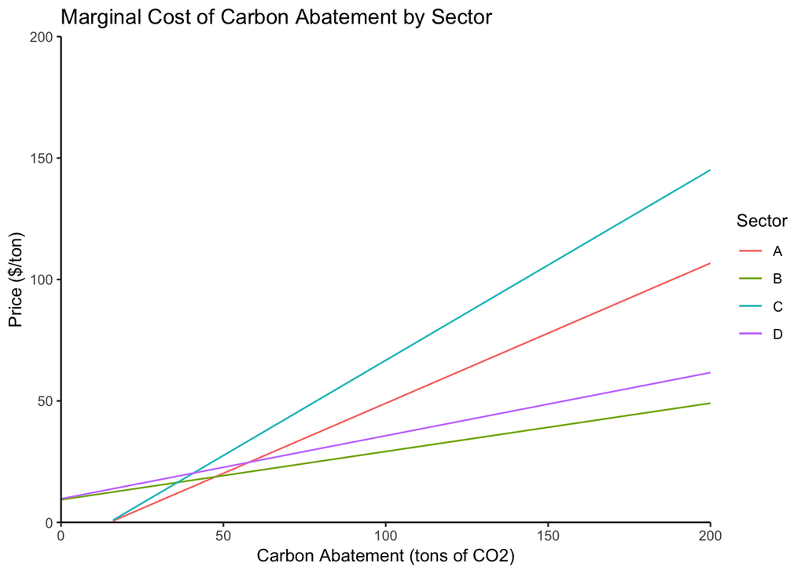

```r
D_int <- MC_D_model$coefficients[1]
D_slope <- MC_D_model$coefficients[2]
#p-value: 0.001121
#R-squared: 0.5108 is worst among them



a_curve <- function(x){A_int + A_slope*x}
b_curve <- function(x){B_int + B_slope*x}
c_curve <- function(x){C_int + C_slope*x}
d_curve <- function(x){D_int + D_slope*x}

mc_plot <- ggplot(data.frame(x=c(0,200)))+
  stat_function(fun=a_curve, aes(color = "A"))+
  stat_function(fun=b_curve, aes(color = "B"))+
  stat_function(fun=c_curve, aes(color = "C"))+
  stat_function(fun=d_curve, aes(color = "D"))+
  scale_x_continuous(limits = c(0,200), expand = c(0,0))+
  scale_y_continuous(limits = c(0,200), expand = c(0,0))+
  labs(fil = "",
       color = "Sector",
       x = "Carbon Abatement (tons of CO2)",
       y = "Price ($/ton)",
       title = "Marginal Cost of Carbon Abatement by Sector")+
  theme_classic()

mc_plot
```

2. Using these models and the current level of carbon emissions, derive each sector’s demand curve for carbon emissions. In other words, how much would each sector be willing to pay for the right to pollute the first unit, second unit, etc? Draw these demand curves on a graph. Which sector is willing to pay the most for the first unit of carbon emissions?

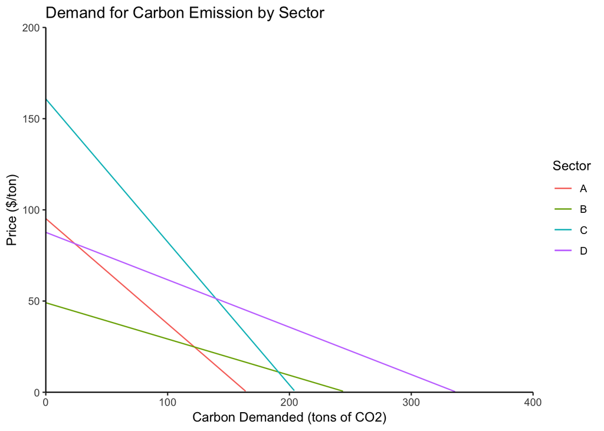

```r
#Current carbon emissions in the sectors are: (A=180, B=200, C=220, and D=300)

# demand function for sector A
q_A <- seq(0,180,by=10)

d_A <- function(x){(A_slope*(180-x)) + A_int}

demand_A <- d_A(q_A)
#WTP for first unit is $95.19


# demand function for sector B
q_B <- seq(0,200,by=10)

d_B <- function(q){(B_slope*(200-q) + B_int)}

demand_B <- d_B(q_B)
#WTP for first unit is $49.07


# demand function for sector C
q_C <- seq(0,220,by=10)

d_C <- function(q){(C_slope*(220-q) + C_int)}

demand_C <- d_C(q_C)
#WTP for first unit is $160.79


# demand function for sector D
q_D <- seq(0,300,by=10)

d_D <- function(q){(D_slope*(300-q) + D_int)}

demand_D <- d_D(q_D)
#WTP for first unit is $87.67


demand_plot <-ggplot(data.frame(x=c(0,200)))+
  stat_function(fun=d_A, aes(color = "A"))+
  stat_function(fun=d_B, aes(color = "B"))+
  stat_function(fun=d_C, aes(color = "C"))+
  stat_function(fun=d_D, aes(color = "D"))+
  scale_x_continuous(limits = c(0,400), expand = c(0,0))+
  scale_y_continuous(limits = c(0,200), expand = c(0,0))+
  labs(fil = "",
       color = "Sector",
       x = "Carbon Demanded (tons of CO2)",
       y = "Price ($/ton)",
       title = "Demand for Carbon Emission by Sector")+
  theme_classic()

demand_plot
```

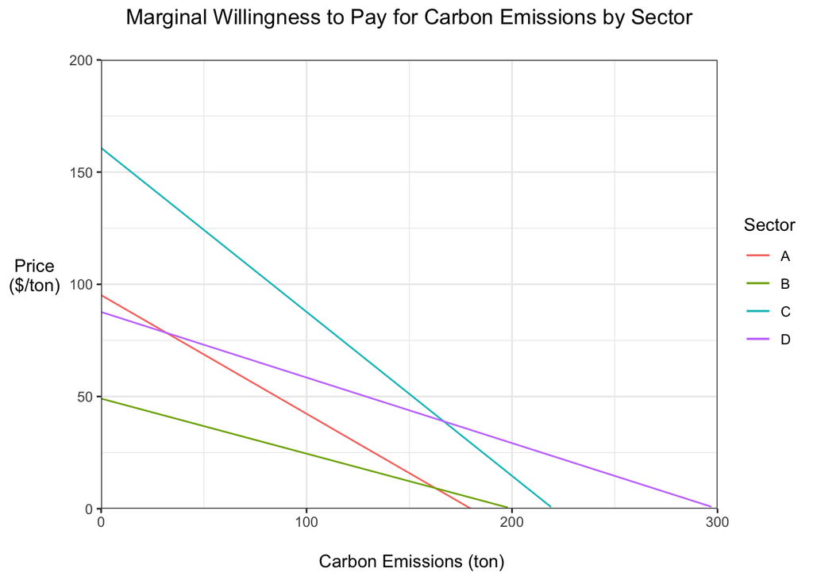

```r
#sector willing to pay the most for the first unit of carbon emissions is C


# Demand curve for Sector A
a_demand_int <- a_curve(180)
a_demand_slope <- (0-a_demand_int)/(180-0)
#demand curve as a function
a_demand_curve <- function(x){
  a_demand_int + a_demand_slope*x}

# Demand curve for Sector B
b_demand_int <- b_curve(200)
b_demand_slope <- (0-b_demand_int)/(200-0)
#demand curve as a function
b_demand_curve <- function(x){
  b_demand_int + b_demand_slope*x}

# Demand curve for Sector C
c_demand_int <- c_curve(220)
c_demand_slope <- (0-c_demand_int)/(220-0)
#demand curve as a function
c_demand_curve <- function(x){
  c_demand_int + c_demand_slope*x}

# Demand curve for Sector D
d_demand_int <- d_curve(300)
d_demand_slope <- (0-d_demand_int)/(300-0)
#demand curve as a function
d_demand_curve <- function(x){
  d_demand_int + d_demand_slope*x}

# Plot demand curves for each sector
demand_plot1 <- ggplot(data.frame(x=c(0,200))) +
  stat_function(fun=a_demand_curve, geom ="line", aes(color = "A")) +
  stat_function(fun=b_demand_curve, geom ="line", aes(color = "B")) +
  stat_function(fun=c_demand_curve, geom ="line", aes(color = "C")) +
  stat_function(fun=d_demand_curve, geom ="line", aes(color = "D")) +
  labs(x = "Abatement", y = "Price")+
  scale_x_continuous(limits =c(0,300), expand = c(0,0))+
  scale_y_continuous(limits=c(0,200), expand=c(0,0))+
  theme_bw() +
  labs(fill = "", color = "Sector") +
  xlab("\n Carbon Emissions (ton)") +
  ylab("Price \n($/ton) \n") +
  ggtitle("Marginal Willingness to Pay for Carbon Emissions by Sector\n") +
  theme(plot.title = element_text(hjust = 0.5),
        axis.title.y = element_text(angle=0, hjust = 0.5, vjust = 0.5))



demand_plot1
```

3. Now focus on country X (which contains sectors A, B, and C). Assume there are no “co-benefits” from carbon abatement (i.e. that there are no local pollutants that are affected by carbon abatement). Suppose to meet the Paris Accord commitments, country X needs to cut all carbon emissions in half. For each of the policy options listed below, derive: (1) the total cost of meeting the target in country X, (2) the cost (or benefit) to each sector, and (3) the tax revenue generated.
1. Cap on carbon. Each sector (A, B, and C) must cut its carbon emissions by 100 tons (thus reducing total emissions from 600 down to 300).
2. Tax on carbon. To emit a ton of carbon in country X, you must pay a tax of $t. You will need to find the tax that accomplishes the desired reduction.
3. Cap and trade. Each sector (A, B, C) is allocated carbon permits equal to their current emissions minus 100 (same as in (a) above), thus achieving the total reduction of 300. Then, these three sectors are allowed to trade with each other. You will need to derive the outcome of that trading.

```r
#Current carbon emissions in the sectors are: (A=180, B=200, C=220, and D=300)

#3a.
#derive: (1) the total cost of meeting the target in country X, (2) the cost (or benefit) to each sector, and (3) the tax revenue generated.(dont think tax revenue applies?)

#(1) total cost of meeting the target (total emissions reduced to 300, by 100 in each sector)

#integrate cost curves from 0-100??
```

4. Again, without any co-benefits, suppose that country Y (which only has one carbon-emitting sector, D) has no obligation to reduce its emissions. Country X asks country Y to enter the country X carbon market. Doing so would require country Y to put a cap on carbon emissions at its current level of emissions (300 tons), but would then allow country Y to sell carbon offsets to sectors A, B, or C. Are there any incentives for country Y to enter country X’s carbon market and to thus place a voluntary cap on its emissions? Are there any incentives for country X to try to attract country Y into its market?
5. Now assume that every ton of carbon emissions creates 1 ton of local air pollution. Local air pollution causes economic damages (health, environmental, etc.), but only in the country in which it is emitted. Assume there are no local air pollution regulations in either country X or country Y.
1. In a carbon cap and trade market that only covers sectors in country X, how much local air pollution would you expect in country X? In country Y?
2. If country Y enters the carbon market for country X (as in question 4 above), how much local pollution will there be in country X and country Y?
3. What advice can you give country X and country Y about the desirability of allowing international trade of carbon emissions credits?